# SI 370 Homework #3

## Taylor Swift songs

Last updated 2023-10-04

The dataset for this assignment is from https://www.kaggle.com/datasets/jarredpriester/taylor-swift-spotify-dataset/data.

**NOTE**: Use the dataset from Canvas rather than the dataset from Kaggle, which is updated frequently and may change while you are completing this assignment.

This dataset consist of data from Spotify's API on all albums listed on Spotify for Taylor Swift. I set up the dataset to update monthly so that if any albums get added it will get added to the dataset too. At first it may look like there are song duplicates but I checked and all song IDs are unique.

The columns in this dataset are:

name - the name of the song

album - the name of the album

release_date - the day month and year the album was released

track number - the order the song appears on the album

id - the Spotify id for the song

uri - the Spotify uri for the song

acousticness - A confidence measure from 0.0 to 1.0 of whether the track is acoustic. 1.0 represents high confidence the track is acoustic.

danceability - Danceability describes how suitable a track is for dancing based on a combination of musical elements including tempo, rhythm stability, beat strength, and overall regularity. A value of 0.0 is least danceable and 1.0 is most danceable.

energy - Energy is a measure from 0.0 to 1.0 and represents a perceptual measure of intensity and activity. Typically, energetic tracks feel fast, loud, and noisy. For example, death metal has high energy, while a Bach prelude scores low on the scale. Perceptual features contributing to this attribute include dynamic range, perceived loudness, timbre, onset rate, and general entropy.

instrumentalness - Predicts whether a track contains no vocals. "Ooh" and "aah" sounds are treated as instrumental in this context. Rap or spoken word tracks are clearly "vocal". The closer the instrumentalness value is to 1.0, the greater likelihood the track contains no vocal content. Values above 0.5 are intended to represent instrumental tracks, but confidence is higher as the value approaches 1.0.

liveness - Detects the presence of an audience in the recording. Higher liveness values represent an increased probability that the track was performed live. A value above 0.8 provides strong likelihood that the track is live.

loudness - The overall loudness of a track in decibels (dB). Loudness values are averaged across the entire track and are useful for comparing relative loudness of tracks. Loudness is the quality of a sound that is the primary psychological correlate of physical strength (amplitude). Values typically range between -60 and 0 db.

speechiness - detects the presence of spoken words in a track. The more exclusively speech-like the recording (e.g. talk show, audio book, poetry), the closer to 1.0 the attribute value. Values above 0.66 describe tracks that are probably made entirely of spoken words. Values between 0.33 and 0.66 describe tracks that may contain both music and speech, either in sections or layered, including such cases as rap music. Values below 0.33 most likely represent music and other non-speech-like tracks.

tempo - The overall estimated tempo of a track in beats per minute (BPM). In musical terminology, tempo is the speed or pace of a given piece and derives directly from the average beat duration.

valence - A measure from 0.0 to 1.0 describing the musical positiveness conveyed by a track. Tracks with high valence sound more positive (e.g. happy, cheerful, euphoric), while tracks with low valence sound more negative (e.g. sad, depressed, angry).

popularity - the popularity of the song from 0 to 100

duration_ms - The duration of the track in milliseconds.

We are going to refer to the tracks' properties of danceability, energy, instrumentalness, liveness, loudness, speechiness, tempo, and valence as "features" of the tracks.

Each of the questions is worth the same number of points, except for the final bonus question, which is worth up to an additional 1 point (out of 20). Points will be allocated according to the following rubric:

- 90-100%: Question is correctly and completely answered. Answer consists of well-written code that conforms to [PEP 8](https://www.python.org/dev/peps/pep-0008/) guidelines and is accompanied by a written interpretation in a Markdown block. Written interpretation does not contain spelling, grammar or stylistic errors (see [Strunk & White](https://drive.google.com/file/d/1L0P7xJwjUGBvyb49mL3dw1Bt7hzRTiTl/view?usp=sharing) for a detailed specifications). Minor problems, such as formatting, incorrect submissions, missing names, etc. will result in less than 100%.
- 75-85% : Answer is mostly complete and correct; two or fewer noticeable omissions or errors. Minor stylistic flaws, either in code or in written interpretation.
- 50-70%: Answer has significant omissions or errors; Noticeable departure from PEP-8 guildelines and/or moderate spelling, grammar, or style issues in written interpretations.
- 25-45%: Question is perfunctorily attempted. Substantial parts are missing or incorrect.
- 0 points: Question not attempted.

Be sure to include interpretations of your results for each question.

Q1: Show the distribution of the popularity of the songs. Then exclude the songs that are from karaoke albums (i.e., the album name contains "karaoke"). Show the distribution of the popularity of the songs. What is the difference between the two distributions?

```python
import pandas as pd
import seaborn as sns
import numpy as np
import matplotlib.pyplot as plt
import statsmodels
import statsmodels.api as sm
import statsmodels.formula.api as smf
from statsmodels.formula.api import ols

taylor_swift_spotify = pd.read_csv("../data/taylor_swift_spotify.csv")
```

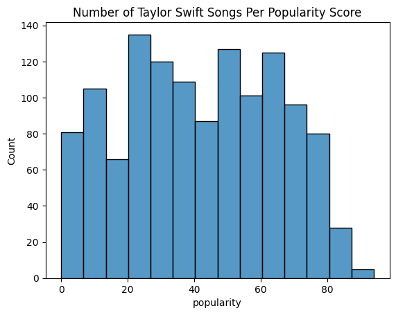

```python
sns.histplot(data=taylor_swift_spotify, x='popularity')
plt.title('Number of Taylor Swift Songs Per Popularity Score')
```

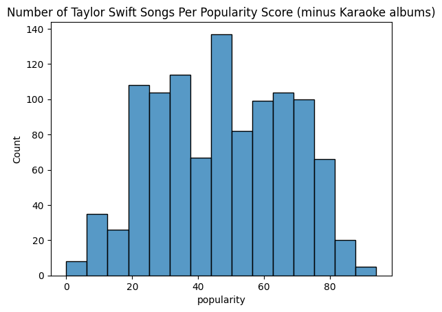

```python
mask = taylor_swift_spotify['album'].str.contains('Karaoke')
ts_not_karaoke = taylor_swift_spotify[~mask]
sns.histplot(data=ts_not_karaoke, x='popularity')
plt.title('Number of Taylor Swift Songs Per Popularity Score (minus Karaoke albums)')
```

### IMPORTANT NOTE: the remainder of the questions are based on the songs that are NOT from karaoke albums.

Q2: Report the average track duration for each album. You answer should be in mm:ss (minutes:seconds) format rather than the milliseconds that are reported in the original dataset.

```python
avg_track_length = pd.to_datetime(ts_not_karaoke.groupby('album')['duration_ms'].mean(),unit="ms").dt.strftime('%M:%S')
avg_track_length.sort_values(ascending=True)
```

```
album
Taylor Swift (Big Machine Radio Release Special)                                       02:26
Fearless (Big Machine Radio Release Special)                                           02:33
1989 (Big Machine Radio Release Special)                                               02:37
Red (Big Machine Radio Release Special)                                                02:38
reputation (Big Machine Radio Release Special)                                         02:44
Speak Now (Big Machine Radio Release Special)                                          02:59
Midnights                                                                              03:23
Lover                                                                                  03:26
Midnights (3am Edition)                                                                03:28
Live From Clear Channel Stripped 2008                                                  03:29
Taylor Swift                                                                           03:33
1989 (Deluxe)                                                                          03:37
1989 (Deluxe Edition)                                                                  03:41
reputation                                                                             03:43
1989                                                                                   03:45
folklore (deluxe version)                                                              03:56
folklore: the long pond studio sessions (from the Disney+ special) [deluxe edition]    03:57
folklore                                                                               03:58
Fearless (International Version)                                                       04:00
Fearless                                                                               04:00
reputation Stadium Tour Surprise Song Playlist                                         04:02
evermore                                                                               04:03
evermore (deluxe version)                                                              04:03
Red                                                                                    04:04
Fearless (Taylor's Version)                                                            04:05
Red (Deluxe Edition)                                                                   04:06
Fearless Platinum Edition                                                              04:10
Fearless (Platinum Edition)                                                            04:10
Red (Taylor's Version)                                                                 04:21
Speak Now (Deluxe Package)                                                             04:35
Speak Now (Deluxe Edition)                                                             04:35
Speak Now (Japanese Version)                                                           04:46
Speak Now (US Version)                                                                 04:47
Speak Now                                                                              04:47
Speak Now World Tour Live                                                              04:57
Name: duration_ms, dtype: object
```

There are many Taylor Swift albums represented in the data set, but the average track lengths for her original albums are as follows: Fearless: 4:00 Speak Now: 4:47 Red: 4:04 1989: 3:45 Reputation: 3:43 Lover: 3:26 Folklore: 3:58 Evermore: 4:03 Midnights: 3:23

Q3: Show a heatmap of the correlations between the features. Use a diverging colormap with white in the middle (i.e. white at a correlation of 0.0).

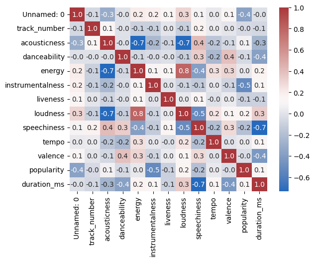

```python
ts_numerical_scores = taylor_swift_spotify.drop(['name', 'album', 'release_date', 'id', 'uri'], axis=1)
sns.heatmap(ts_numerical_scores.corr(), annot=True, fmt=".1f", cmap="vlag")
```

Q4: List the top 5 correlations between the features of the songs.

```python
ts_numerical_scores.corr().unstack().sort_values(ascending=False).drop_duplicates()[1:6]
```

```
loudness     energy          0.798154
speechiness  acousticness    0.410377
valence      danceability    0.386819
speechiness  danceability    0.331066
loudness     duration_ms     0.329872
dtype: float64
```

Out of the top 5 correlations between song features, the strongest correlation exists between loudness and energy of the song.

Q5: Does the position of the track on the album (i.e. track number) have an effect on the popularity of the song? Use both visual and statistical evidence to support your answer.

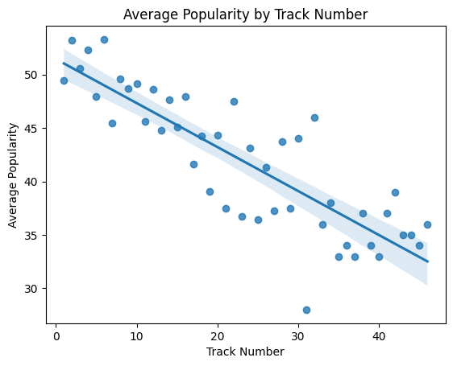

```python
avg_pop_df = ts_not_karaoke['popularity'].groupby(ts_not_karaoke['track_number']).mean().reset_index()
sns.regplot(data=avg_pop_df, x='track_number', y='popularity')
plt.xlabel('Track Number')
plt.ylabel('Average Popularity')
plt.title('Average Popularity by Track Number')
```

```python
ts_not_karaoke['popularity'].corr(ts_not_karaoke['track_number'])
```

```
-0.17403554033698437
```

There is a negative correlation between average popularity and track number. The tracks that appear earlier on the album tend to be more popular on average than tracks that occur at the end of an album. Above I created the visualization based on average popularity for a more readable graph. Below that I found the correlation between popularity and track number to be -0.17 which supports my argument that there is a negative correlation there. However, it is not a large correlation.

Q6: Are popular songs more danceable? Divide the songs into popular (i.e. those with a popularity rating of 60 or higher) and less popular (i.e. those with a popularity rating of less than 60). Conduct an ANOVA test for the two groups of data based on danceability feature. Are they statistically significant?

```python
def pop_or_not(x):
    if x < 60:
        label = 'less_popular'
    if x >= 60:
        label = 'popular'
    return label
```

```python
ts_not_karaoke['pop_or_not'] = ts_not_karaoke.popularity.apply(pop_or_not)
```

```python
mask1 = (ts_not_karaoke['pop_or_not'] == 'popular')
ts_popular = ts_not_karaoke[mask1]
len(ts_popular)
```

```
345
```

```python
ts_lm = ols('pop_or_not ~ danceability', data=ts_popular).fit()
table = sm.stats.anova_lm(ts_lm, typ=2)
table
```

|  | sum_sq | df | F | PR(>F) |
| --- | --- | --- | --- | --- |
| danceability | 1.873649e-33 | 1.0 | 0.004198 | 0.948378 |
| Residual | 1.530883e-28 | 343.0 | NaN | NaN |

Q7: Create a regression model with "popularity" as the dependent variable and "liveness" as the predictor variable. Report the following:

1. Coefficient of determination (i.e. $r^2$)
2. Whether the regression is statistically significant
3. An estimate for the value of "popularity" when the value of "liveness" is 0.22.

```python
model0 = smf.ols('popularity ~ liveness', data=ts_not_karaoke).fit()
model0.summary()
```

OLS Regression Results

| Dep. Variable: | popularity | R-squared: | 0.009 |
| --- | --- | --- | --- |
| Model: | OLS | Adj. R-squared: | 0.008 |
| Method: | Least Squares | F-statistic: | 10.12 |
| Date: | Mon, 09 Oct 2023 | Prob (F-statistic): | 0.00150 |
| Time: | 21:25:00 | Log-Likelihood: | -4743.8 |
| No. Observations: | 1075 | AIC: | 9492. |
| Df Residuals: | 1073 | BIC: | 9502. |
| Df Model: | 1 |  |  |
| Covariance Type: | nonrobust |  |  |

|  | coef | std err | t | P>\|t\| | [0.025 | 0.975] |
| --- | --- | --- | --- | --- | --- | --- |
| Intercept | 49.8667 | 1.017 | 49.048 | 0.000 | 47.872 | 51.862 |
| liveness | -16.1986 | 5.091 | -3.182 | 0.002 | -26.188 | -6.210 |

| Omnibus: | 183.152 | Durbin-Watson: | 0.400 |
| --- | --- | --- | --- |
| Prob(Omnibus): | 0.000 | Jarque-Bera (JB): | 41.318 |
| Skew: | -0.056 | Prob(JB): | 1.07e-09 |
| Kurtosis: | 2.046 | Cond. No. | 8.57 |

Notes:  
[1] Standard Errors assume that the covariance matrix of the errors is correctly specified.

```python
49.8667 + -16.1986*0.22
```

```
46.303008000000005
```

The coefficient of determination is 0.009 The regression is statistically significant because the probability of the F statistic is .00150 which is less than .05. When liveness is 0.22, popularity is predicted to be 46.30 according to the model.

Q8: Due to intellectual property conflicts, Taylor Swift re-recorded some of her earlier albums, including `Fearless`, `Red` and `Speak Now`. We assume that re-recording her early albums will allow Taylor Swift to reclaim her artistry control, revisit the songs and make any changes she wants. Therefore, we want to see whether the new songs are more loved by the audiences by looking at the popularity score.

- The re-recorded ones have `(Taylor’s version)` at the end of the album name.
- We will ignore the Speak Now World Tour Live version. Therefore there are 5 albums as original and 3 as re-recorded

a) Create a visualization that shows the distribution of popularity scores of original vs. re-recorded songs. There are multiple visualizations that would be appropriate here. You can choose any of them. At a minimum, you should create one visualization. Creating additional ones can earn you additional points.

b) Is there a statistically significant difference between the popularity scores of the original and re-recorded songs? If so, which one is more popular? How much more popular is it, on average?

```python
mask3 = ts_not_karaoke['album'].str.contains('Fearless|Red', regex=True)
re_records = ts_not_karaoke[mask3]
re_records.album.unique()
```

```
array(["Red (Taylor's Version)", "Fearless (Taylor's Version)", 'Red',
       'Red (Deluxe Edition)', 'Red (Big Machine Radio Release Special)',
       'Fearless', 'Fearless (International Version)',
       'Fearless (Big Machine Radio Release Special)',
       'Fearless (Platinum Edition)', 'Fearless Platinum Edition'],
      dtype=object)
```

```python
re_records['tay_version'] = re_records['album'].apply(lambda x: True if "Taylor's Version" in x else False)
re_records.tay_version.unique()
```

```
array([ True, False])
```

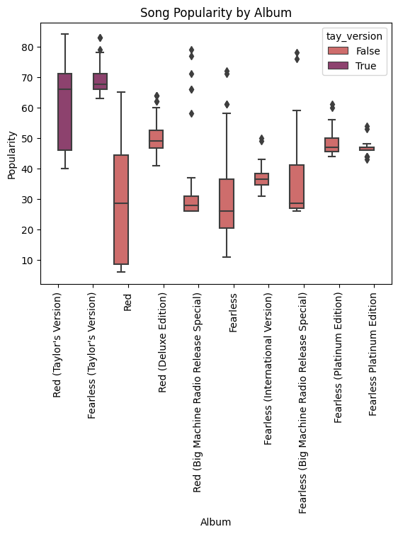

```python
sns.boxplot(data=re_records, x='album', y='popularity', hue='tay_version', palette='flare')
plt.xticks(rotation=90)
plt.xlabel('Album')
plt.ylabel('Popularity')
plt.title('Song Popularity by Album')
```

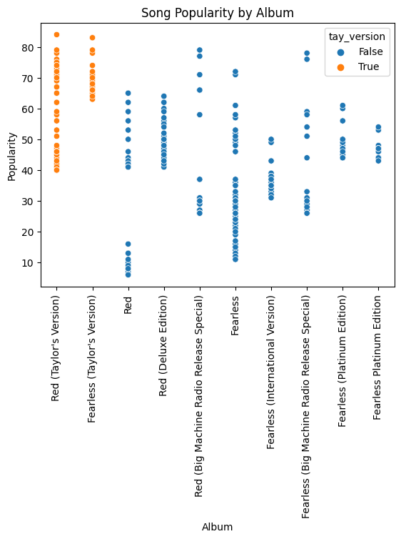

```python
sns.scatterplot(data=re_records, x='album', y='popularity', hue='tay_version')
plt.xticks(rotation=90)
plt.xlabel('Album')
plt.ylabel('Popularity')
plt.title('Song Popularity by Album')
```

```python
sm.stats.anova_lm(ols('popularity ~ tay_version', data=re_records).fit(), typ=2)
```

|  | sum_sq | df | F | PR(>F) |
| --- | --- | --- | --- | --- |
| tay_version | 39282.339292 | 1.0 | 171.949044 | 5.431048e-32 |
| Residual | 76531.880293 | 335.0 | NaN | NaN |

```python
re_records.groupby('tay_version').popularity.mean()[True] - re_records.groupby('tay_version').popularity.mean()[False]
```

```
24.764384323172422
```

BONUS, worth up to 1 point: How would you determine whether [Taylor Swift has had an effect on the popularity of football](https://duckduckgo.com/?q=taylor+swift+football&atb=v314-1&ia=web)? What data would you need? What analysis would you perform? What would you expect the results to be?

### Submit your completed assignment in both IPYNB and HTML formats.